# Hadi Babalou - 810199380

In this notebook, we will implement a convolutional neural network (CNN) for image classification. We will use the CIFAR-10 dataset, which consists of 60000 32x32 colour images in 10 classes.

## Loading and Preprocessing Data

```python
import numpy as np
import pandas as pd
import matplotlib.pyplot as plt
import tensorflow as tf
from tensorflow import keras
from sklearn.metrics import classification_report
```

### Loading Data

```python
cifar10 = keras.datasets.cifar10
```

```python
(X_train, y_train), (X_test, y_test) = cifar10.load_data()
```

```python
labels_names = ['airplane', 'automobile', 'bird', 'cat', 'deer', 'dog', 'frog', 'horse', 'ship', 'truck']
```

### A quick look at the data

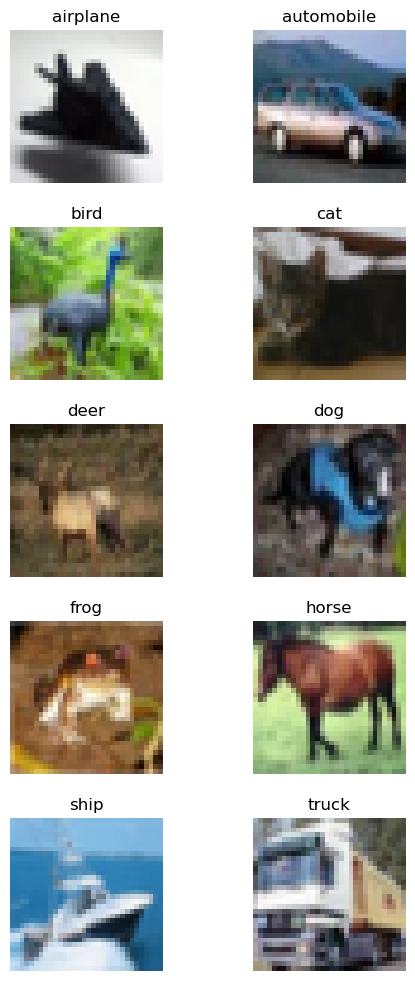

```python
import matplotlib.pyplot as plt

NUM_OF_CLASSES = 10
ROWS = 5
COLS = 2
fig, ax = plt.subplots(ROWS, COLS, figsize=(5, 10))
fig.tight_layout()
for i in range(NUM_OF_CLASSES):
    ax[i//COLS][i%COLS].imshow(X_train[np.where(y_train==i)[0][0]])
    ax[i//COLS][i%COLS].set_title(labels_names[i])
    ax[i//COLS][i%COLS].axis('off')
plt.show()
```

### Count of each class

```python
labels_count_train = np.zeros(NUM_OF_CLASSES)
for i in range(NUM_OF_CLASSES):
    labels_count_train[i] = np.sum(y_train==i)
```

```python
labels_count_test = np.zeros(NUM_OF_CLASSES)
for i in range(NUM_OF_CLASSES):
    labels_count_test[i] = np.sum(y_test==i)
```

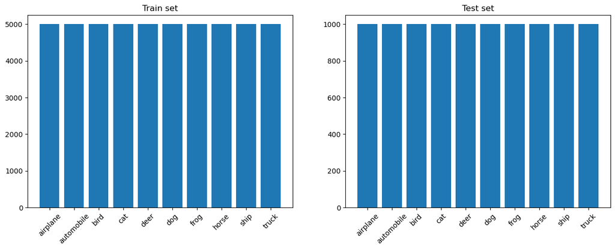

```python
fig, ax = plt.subplots(1, 2, figsize=(15, 5))
ax[0].bar(np.arange(NUM_OF_CLASSES), labels_count_train)
ax[0].set_title('Train set')
ax[0].set_xticks(np.arange(NUM_OF_CLASSES))
ax[0].set_xticklabels(labels_names, rotation=45)
ax[1].bar(np.arange(NUM_OF_CLASSES), labels_count_test)
ax[1].set_title('Test set')
ax[1].set_xticks(np.arange(NUM_OF_CLASSES))
ax[1].set_xticklabels(labels_names, rotation=45)
plt.show()
```

### Normalizing the data

```python
X_train = X_train / 255.0
X_test = X_test / 255.0
```

### One hot encoding the labels

```python
from keras.utils import to_categorical

y_train_cat = to_categorical(y_train, NUM_OF_CLASSES)
y_test_cat = to_categorical(y_test, NUM_OF_CLASSES)
```

## Classification with CNN

```python
from keras.models import Sequential
from keras.layers import Conv2D, MaxPooling2D, Flatten, Dense, Activation, Input
from keras.layers import BatchNormalization, Dropout
from keras.optimizers import Adam
```

### Creating the model

```python
def create_model(learning_rate=0.0001, dropout=False, batch_norm=False):
    model = Sequential()

    model.add(Conv2D(filters=64, kernel_size=(3, 3), padding='same', activation='relu', input_shape=(32, 32, 3)))
    if batch_norm:
        model.add(BatchNormalization())
    model.add(Conv2D(filters=64, kernel_size=(3, 3), padding='same', activation='relu'))
    if batch_norm:
        model.add(BatchNormalization())
    model.add(MaxPooling2D(pool_size=(2, 2), strides=(2, 2)))

    model.add(Conv2D(filters=128, kernel_size=(3, 3), padding='same', activation='relu'))
    if batch_norm:
        model.add(BatchNormalization())
    model.add(Conv2D(filters=128, kernel_size=(3, 3), padding='same', activation='relu'))
    if batch_norm:
        model.add(BatchNormalization())
    model.add(MaxPooling2D(pool_size=(2, 2), strides=(2, 2)))

    model.add(Flatten())

    model.add(Dense(units=1024, activation='relu'))
    if dropout:
        model.add(Dropout(0.2))
    model.add(Dense(units=1024, activation='relu'))
    if dropout:
        model.add(Dropout(0.4))
    model.add(Dense(units=NUM_OF_CLASSES, activation='softmax'))

    model.compile(loss='categorical_crossentropy', optimizer=Adam(learning_rate=learning_rate), metrics=['accuracy'])

    return model
```

### Adam Optimizer

The Adam optimizer is an optimization algorithm commonly used in machine learning and deep learning models. It stands for Adaptive Moment Estimation and is known for its effectiveness and efficiency in training neural networks.

Adam combines the benefits of two other optimization methods: adaptive learning rate methods and momentum-based methods. It calculates individual adaptive learning rates for different model parameters based on estimates of the first and second moments of the gradients.

Here is an overview of the Adam optimization algorithm:

1. Initialization:

   ```
   Adam initializes two variables, namely m and v, which are vectors of zeros with the same shape as the model's parameters. These variables are used to store the first and second moments of the gradients.
   It also initializes a variable called t to keep track of the number of updates performed.
   ```

2. Computing Gradients:

   ```
   In each iteration of the optimization process, the gradients of the model's parameters are computed using backpropagation.
   ```

3. Updating the First Moment Estimate:

   ```
   Adam updates the first moment estimate m by calculating a weighted average of the current gradients and the previous value of m. The weight is controlled by a hyperparameter called beta1 (typically set to 0.9).
   The update equation is:
   $$ m = \beta_1 m + (1 - \beta_1) \times gradients $$
   ```

4. Updating the Second Moment Estimate:

   ```
   Similarly, Adam updates the second moment estimate v by calculating a weighted average of the squared gradients and the previous value of v. The weight is controlled by a hyperparameter called beta2 (typically set to 0.999).
   The update equation is:
   $$ v = \beta_2 v + (1 - \beta_2) \times gradients^2 $$
   ```

5. Bias Correction:

   ```
   The m and v estimates are biased towards zero, especially in the early iterations. To correct this bias, Adam performs a bias correction step by dividing the estimates by a correction factor.
   The bias-corrected first moment estimate is:
   $$ m_{hat} = \frac{m}{1 - \beta_1^t} $$
   The bias-corrected second moment estimate is:
   $$ v_{hat} = \frac{v}{1 - \beta_2^t} $$
   ```

6. Parameter Update:

   ```
   Finally, the model's parameters are updated using the bias-corrected estimates. The learning rate lr (another hyperparameter) controls the step size of the update.
   The update equation is:
   $$ parameter = parameter - learning\ rate \times \frac{m_{hat}}{\sqrt{v_{hat}} + \epsilon} $$
   Here, epsilon is a small value (e.g., 1e-8) added to the denominator for numerical stability.
   ```

7. Repeat:

   ```
   Steps 2-6 are repeated for a specified number of iterations or until a convergence criterion is met.
   ```

There are some differences between Adam and SGD. such as:

1. Adaptive Learning Rates: In SGD, a fixed learning rate is used for all parameters, which can sometimes lead to slow convergence or overshooting. In Adam, adaptive learning rates are computed for each parameter individually, based on the first and second moments of the gradients. This allows the learning rates to be adjusted automatically based on the characteristics of each parameter, resulting in faster convergence.
2. Momentum: SGD with momentum is an extension of the basic SGD algorithm that adds a fraction of the previous update to the current update, allowing the optimization process to overcome local minima and accelerate convergence. Adam also incorporates the concept of momentum by utilizing the first moment (mean) of the gradients, which helps in smoothing out the updates and improving convergence.
3. Parameter-specific Learning Rates: In Adam, the learning rates are computed based on the estimates of the first and second moments of the gradients for each parameter. This enables the algorithm to adaptively adjust the learning rates based on the behavior of individual parameters. In contrast, SGD uses a single learning rate for all parameters, which can be less efficient when dealing with different types of parameters.
4. Initialization: SGD typically requires careful tuning of the learning rate and momentum hyperparameters to achieve good performance, whereas Adam is less sensitive to the choice of hyperparameters and often requires less manual tuning. The default hyperparameter values for Adam are often suitable for a wide range of tasks.
5. Computational Complexity: Adam requires storing and updating additional parameters for the first and second moment estimates, which increases the memory requirements and computational complexity compared to basic SGD. However, the benefits of adaptive learning rates and momentum can often outweigh the additional computational cost, especially in large-scale models.

The Adam optimizer incorporates adaptive learning rates and momentum to overcome some limitations of basic SGD. It offers faster convergence, automatic adjustment of learning rates for individual parameters, and requires less manual hyperparameter tuning. However, it comes with increased memory requirements and computational complexity compared to basic SGD. The choice between Adam and SGD depends on the specific requirements of the problem at hand and may require empirical evaluation to determine the most suitable optimizer.

### Training the model

```python
base_model = create_model()
base_model.summary()
```

```
Model: "sequential_10"
_________________________________________________________________
 Layer (type)                Output Shape              Param #
=================================================================
 conv2d_8 (Conv2D)           (None, 32, 32, 64)        1792

 conv2d_9 (Conv2D)           (None, 32, 32, 64)        36928

 max_pooling2d_4 (MaxPooling  (None, 16, 16, 64)       0
 2D)

 conv2d_10 (Conv2D)          (None, 16, 16, 128)       73856

 conv2d_11 (Conv2D)          (None, 16, 16, 128)       147584

 max_pooling2d_5 (MaxPooling  (None, 8, 8, 128)        0
 2D)

 flatten_2 (Flatten)         (None, 8192)              0

 dense_6 (Dense)             (None, 1024)              8389632

 dense_7 (Dense)             (None, 1024)              1049600

 dense_8 (Dense)             (None, 10)                10250

=================================================================
Total params: 9,709,642
Trainable params: 9,709,642
Non-trainable params: 0
_________________________________________________________________
```

```python
base_model_log = base_model.fit(X_train, y_train_cat, batch_size=32, epochs=20, validation_data=(X_test, y_test_cat))
```

### Evaluating the model

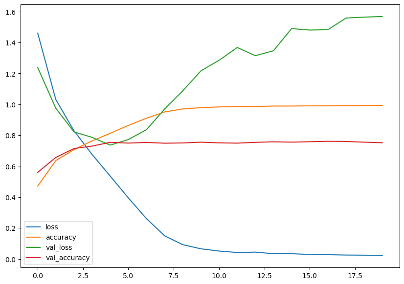

```python
pd.DataFrame(base_model_log.history).plot(figsize=(10, 7))
```

```python
base_model_evaluations = base_model.evaluate(X_test, y_test_cat)

print(f'Test Loss: {base_model_evaluations[0]:.3f}')
print(f'Test Accuracy: {base_model_evaluations[1]:.3f}')

evaluation_results_df = pd.DataFrame(data=[base_model_evaluations], columns=['Loss', 'Accuracy'])
evaluation_results_df
```

```
Test Loss: 1.568
Test Accuracy: 0.751
```

|  | Loss | Accuracy |
| --- | --- | --- |
| 0 | 1.568301 | 0.7513 |

```python
y_pred = base_model.predict(X_test)
y_pred_bool = np.argmax(y_pred, axis=1)
print(classification_report(y_test, y_pred_bool))
```

```
              precision    recall  f1-score   support

           0       0.78      0.81      0.79      1000
           1       0.86      0.87      0.87      1000
           2       0.67      0.65      0.66      1000
           3       0.59      0.55      0.57      1000
           4       0.68      0.75      0.71      1000
           5       0.63      0.69      0.66      1000
           6       0.90      0.66      0.77      1000
           7       0.76      0.83      0.79      1000
           8       0.85      0.85      0.85      1000
           9       0.82      0.86      0.84      1000

    accuracy                           0.75     10000
   macro avg       0.76      0.75      0.75     10000
weighted avg       0.76      0.75      0.75     10000
```

## Unbalanced Data

### Unbalancing the data

We are going to unbalance the data by removing 80% of the samples from the class 0 and 1.

```python
X_train_rest = X_train[(y_train[:, 0] != 0) & (y_train[:, 0] != 1)]
y_train_rest = y_train[(y_train[:, 0] != 0) & (y_train[:, 0] != 1)]

# remove 80% of the samples from class 0
X_train_class0 = X_train[y_train[:, 0] == 0]
y_train_class0 = y_train[y_train[:, 0] == 0]
X_train_class0 = X_train_class0[:int(0.2 * len(X_train_class0))]
y_train_class0 = y_train_class0[:int(0.2 * len(y_train_class0))]
X_train_modified = np.concatenate((X_train_rest, X_train_class0))
y_train_modified = np.concatenate((y_train_rest, y_train_class0))

# remove 80% of the samples from class 1
X_train_class1 = X_train[y_train[:, 0] == 1]
y_train_class1 = y_train[y_train[:, 0] == 1]
X_train_class1 = X_train_class1[:int(0.2 * len(X_train_class1))]
y_train_class1 = y_train_class1[:int(0.2 * len(y_train_class1))]
X_train_modified = np.concatenate((X_train_modified, X_train_class1))
y_train_modified = np.concatenate((y_train_modified, y_train_class1))
```

```python
labels_count_train = np.zeros(NUM_OF_CLASSES)
for i in range(NUM_OF_CLASSES):
    labels_count_train[i] = np.sum(y_train_modified==i)
```

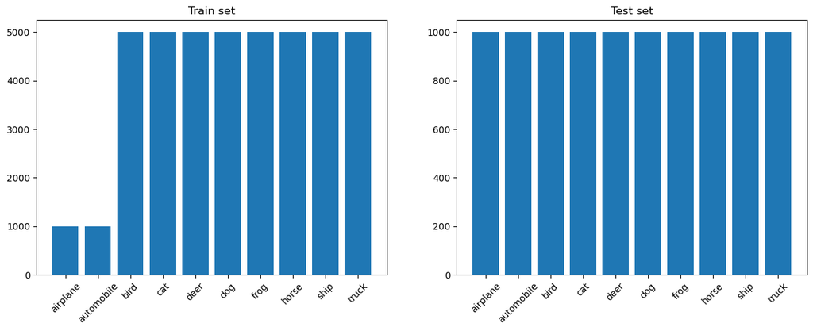

```python
fig, ax = plt.subplots(1, 2, figsize=(15, 5))
ax[0].bar(np.arange(NUM_OF_CLASSES), labels_count_train)
ax[0].set_title('Train set')
ax[0].set_xticks(np.arange(NUM_OF_CLASSES))
ax[0].set_xticklabels(labels_names, rotation=45)
ax[1].bar(np.arange(NUM_OF_CLASSES), labels_count_test)
ax[1].set_title('Test set')
ax[1].set_xticks(np.arange(NUM_OF_CLASSES))
ax[1].set_xticklabels(labels_names, rotation=45)
plt.show()
```

```python
y_train_modified_cat = to_categorical(y_train_modified, NUM_OF_CLASSES)
```

### Training the model with unbalanced data

```python
unbalanced_model = create_model()
unbalanced_model.summary()
```

```
Model: "sequential_11"
_________________________________________________________________
 Layer (type)                Output Shape              Param #
=================================================================
 conv2d_12 (Conv2D)          (None, 32, 32, 64)        1792

 conv2d_13 (Conv2D)          (None, 32, 32, 64)        36928

 max_pooling2d_6 (MaxPooling  (None, 16, 16, 64)       0
 2D)

 conv2d_14 (Conv2D)          (None, 16, 16, 128)       73856

 conv2d_15 (Conv2D)          (None, 16, 16, 128)       147584

 max_pooling2d_7 (MaxPooling  (None, 8, 8, 128)        0
 2D)

 flatten_3 (Flatten)         (None, 8192)              0

 dense_9 (Dense)             (None, 1024)              8389632

 dense_10 (Dense)            (None, 1024)              1049600

 dense_11 (Dense)            (None, 10)                10250

=================================================================
Total params: 9,709,642
Trainable params: 9,709,642
Non-trainable params: 0
_________________________________________________________________
```

```python
unbalanced_model_log = unbalanced_model.fit(X_train_modified, y_train_modified_cat, batch_size=32, epochs=20, validation_data=(X_test, y_test_cat))
```

### Evaluating the model with unbalanced data

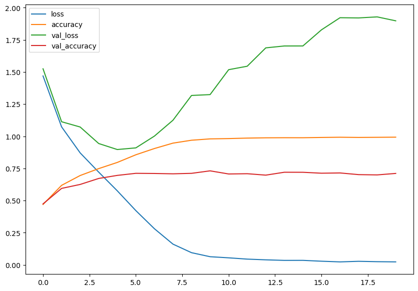

```python
pd.DataFrame(unbalanced_model_log.history).plot(figsize=(10, 7))
```

```python
unbalanced_model_evaluations = unbalanced_model.evaluate(X_test, y_test_cat)

print(f'Test Loss: {unbalanced_model_evaluations[0]:.3f}')
print(f'Test Accuracy: {unbalanced_model_evaluations[1]:.3f}')
```

```
Test Loss: 1.898
Test Accuracy: 0.711
```

```python
y_pred = unbalanced_model.predict(X_test)
y_pred_bool = np.argmax(y_pred, axis=1)
print(classification_report(y_test, y_pred_bool))
```

```
              precision    recall  f1-score   support

           0       0.88      0.52      0.65      1000
           1       0.93      0.60      0.73      1000
           2       0.66      0.63      0.64      1000
           3       0.47      0.68      0.56      1000
           4       0.71      0.67      0.69      1000
           5       0.69      0.62      0.66      1000
           6       0.73      0.84      0.78      1000
           7       0.80      0.80      0.80      1000
           8       0.79      0.86      0.83      1000
           9       0.69      0.88      0.78      1000

    accuracy                           0.71     10000
   macro avg       0.74      0.71      0.71     10000
weighted avg       0.74      0.71      0.71     10000
```

### Comparing the results

The recall and f1-score of these classes decreased significantly, but precision of these classes increased. This is because the model has learned to predict the majority classes and because of the unbalanced data, it has a hard time predicting the minority classes.

## Data Augmentation

```python
# from keras.preprocessing.image import ImageDataGenerator
# image_generator = ImageDataGenerator(rotation_range=10, zoom_range=0.15, width_shift_range=0.1, height_shift_range=0.1, shear_range=0.15, horizontal_flip=True, fill_mode='nearest')

from keras.layers import RandomCrop, RandomFlip, RandomTranslation, RandomRotation, RandomZoom, RandomContrast, RandomBrightness

random_image_generator = Sequential()
random_image_generator.add(RandomCrop(height=32, width=32, seed=42, input_shape=(32, 32, 3)))
random_image_generator.add(RandomFlip(mode='horizontal_and_vertical', seed=42))
random_image_generator.add(RandomTranslation(height_factor=0.1, width_factor=0.1, seed=42))
random_image_generator.add(RandomRotation(factor=0.1, seed=42))
random_image_generator.add(RandomZoom(height_factor=0.2, width_factor=0.2, seed=42))
random_image_generator.add(RandomContrast(factor=0.1, seed=42))
random_image_generator.add(RandomBrightness(factor=0.1, seed=42))
```

```python
# now we have to extend class 0 and class 1 to have the same number of samples as the other classes
X_train_augmented = X_train_modified
for i in range(4):
    X_train_class0_augmented = random_image_generator(X_train_class0)
    X_train_class1_augmented = random_image_generator(X_train_class0)
    X_train_augmented = np.concatenate((X_train_augmented, X_train_class0_augmented, X_train_class1_augmented))
    y_train_modified = np.concatenate((y_train_modified, y_train_class0, y_train_class1))
```

```python
labels_count_train = np.zeros(NUM_OF_CLASSES)
for i in range(NUM_OF_CLASSES):
    labels_count_train[i] = np.sum(y_train_modified==i)
```

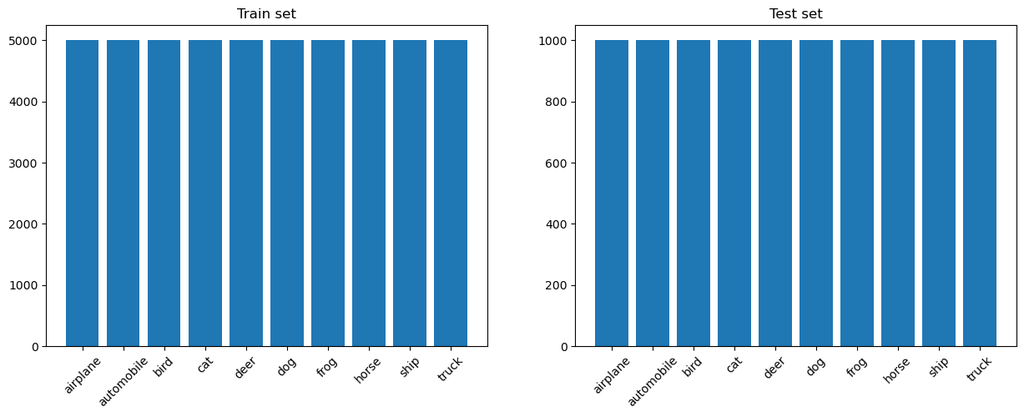

```python
fig, ax = plt.subplots(1, 2, figsize=(15, 5))
ax[0].bar(np.arange(NUM_OF_CLASSES), labels_count_train)
ax[0].set_title('Train set')
ax[0].set_xticks(np.arange(NUM_OF_CLASSES))
ax[0].set_xticklabels(labels_names, rotation=45)
ax[1].bar(np.arange(NUM_OF_CLASSES), labels_count_test)
ax[1].set_title('Test set')
ax[1].set_xticks(np.arange(NUM_OF_CLASSES))
ax[1].set_xticklabels(labels_names, rotation=45)
plt.show()
```

```python
y_train_modified_cat = to_categorical(y_train_modified, NUM_OF_CLASSES)
```

### Training the model with augmented data

```python
augmnented_model = create_model()
augmnented_model.summary()
```

```
Model: "sequential_13"
_________________________________________________________________
 Layer (type)                Output Shape              Param #
=================================================================
 conv2d_16 (Conv2D)          (None, 32, 32, 64)        1792

 conv2d_17 (Conv2D)          (None, 32, 32, 64)        36928

 max_pooling2d_8 (MaxPooling  (None, 16, 16, 64)       0
 2D)

 conv2d_18 (Conv2D)          (None, 16, 16, 128)       73856

 conv2d_19 (Conv2D)          (None, 16, 16, 128)       147584

 max_pooling2d_9 (MaxPooling  (None, 8, 8, 128)        0
 2D)

 flatten_4 (Flatten)         (None, 8192)              0

 dense_12 (Dense)            (None, 1024)              8389632

 dense_13 (Dense)            (None, 1024)              1049600

 dense_14 (Dense)            (None, 10)                10250

=================================================================
Total params: 9,709,642
Trainable params: 9,709,642
Non-trainable params: 0
_________________________________________________________________
```

```python
augmented_model_log = augmnented_model.fit(X_train_augmented, y_train_modified_cat, batch_size=32, epochs=20, validation_data=(X_test, y_test_cat))
```

### Evaluating the model with augmented data

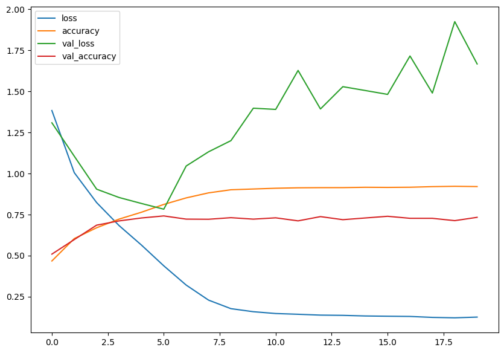

```python
pd.DataFrame(augmented_model_log.history).plot(figsize=(10, 7))
```

```python
augmented_model_evaluations = augmnented_model.evaluate(X_test, y_test_cat)

print(f'Test Loss: {augmented_model_evaluations[0]:.3f}')
print(f'Test Accuracy: {augmented_model_evaluations[1]:.3f}')
```

```
Test Loss: 1.667
Test Accuracy: 0.733
```

```python
y_pred_augmented = augmnented_model.predict(X_test)
y_pred_augmented_bool = np.argmax(y_pred_augmented, axis=1)
print(classification_report(y_test, y_pred_augmented_bool))
```

```
              precision    recall  f1-score   support

           0       0.81      0.64      0.71      1000
           1       0.88      0.67      0.76      1000
           2       0.74      0.63      0.68      1000
           3       0.57      0.58      0.58      1000
           4       0.76      0.72      0.74      1000
           5       0.61      0.71      0.66      1000
           6       0.75      0.84      0.79      1000
           7       0.81      0.80      0.80      1000
           8       0.81      0.86      0.84      1000
           9       0.68      0.89      0.77      1000

    accuracy                           0.73     10000
   macro avg       0.74      0.73      0.73     10000
weighted avg       0.74      0.73      0.73     10000
```

### Comparing the results

As we can see the accuracy of the model is better than the model trained with unbalanced data but it is still a little bit lower than the model trained with balanced data.

Also recall and f1-score of the minority classes are better than the model trained with unbalanced data but they are still lower than the model trained with balanced data.

## Regularization

### Training the model with original data and regularization

```python
final_model = create_model(dropout=True, batch_norm=True)
final_model.summary()
```

```
Model: "sequential_14"
_________________________________________________________________
 Layer (type)                Output Shape              Param #
=================================================================
 conv2d_20 (Conv2D)          (None, 32, 32, 64)        1792

 batch_normalization (BatchN  (None, 32, 32, 64)       256
 ormalization)

 conv2d_21 (Conv2D)          (None, 32, 32, 64)        36928

 batch_normalization_1 (Batc  (None, 32, 32, 64)       256
 hNormalization)

 max_pooling2d_10 (MaxPoolin  (None, 16, 16, 64)       0
 g2D)

 conv2d_22 (Conv2D)          (None, 16, 16, 128)       73856

 batch_normalization_2 (Batc  (None, 16, 16, 128)      512
 hNormalization)

 conv2d_23 (Conv2D)          (None, 16, 16, 128)       147584

 batch_normalization_3 (Batc  (None, 16, 16, 128)      512
 hNormalization)

 max_pooling2d_11 (MaxPoolin  (None, 8, 8, 128)        0
 g2D)

 flatten_5 (Flatten)         (None, 8192)              0

 dense_15 (Dense)            (None, 1024)              8389632

 dropout (Dropout)           (None, 1024)              0

 dense_16 (Dense)            (None, 1024)              1049600

 dropout_1 (Dropout)         (None, 1024)              0

 dense_17 (Dense)            (None, 10)                10250

=================================================================
Total params: 9,711,178
Trainable params: 9,710,410
Non-trainable params: 768
_________________________________________________________________
```

```python
final_model_log = final_model.fit(X_train, y_train_cat, batch_size=32, epochs=40, validation_data=(X_test, y_test_cat))
```

### Evaluating the model with original data and regularization

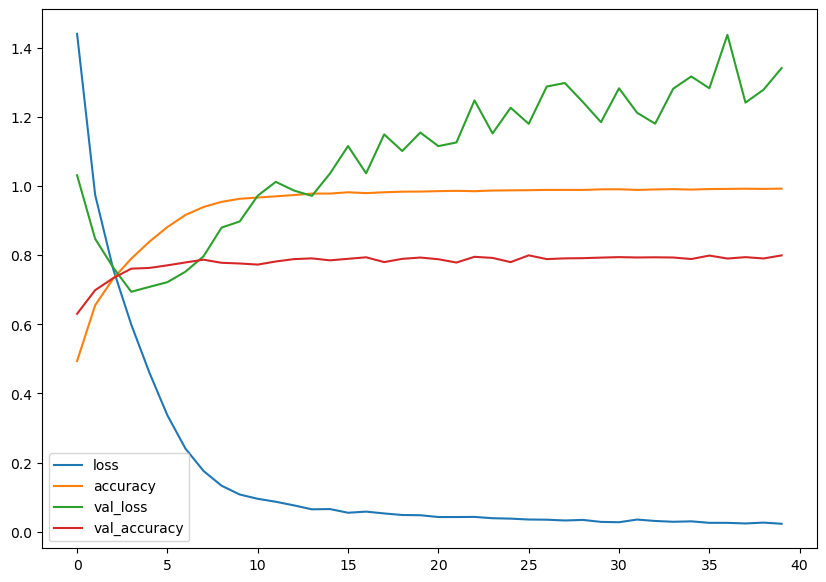

```python
pd.DataFrame(final_model_log.history).plot(figsize=(10, 7))
```

```python
final_model_evaluations = final_model.evaluate(X_test, y_test_cat)

print(f'Test Loss: {final_model_evaluations[0]:.3f}')
print(f'Test Accuracy: {final_model_evaluations[1]:.3f}')
```

```
Test Loss: 1.342
Test Accuracy: 0.800
```

```python
y_pred_final = final_model.predict(X_test)
y_pred_final_bool = np.argmax(y_pred_final, axis=1)
print(classification_report(y_test, y_pred_final_bool))
```

```
              precision    recall  f1-score   support

           0       0.83      0.83      0.83      1000
           1       0.83      0.93      0.88      1000
           2       0.77      0.70      0.73      1000
           3       0.64      0.62      0.63      1000
           4       0.77      0.79      0.78      1000
           5       0.68      0.74      0.71      1000
           6       0.83      0.85      0.84      1000
           7       0.85      0.84      0.85      1000
           8       0.88      0.88      0.88      1000
           9       0.93      0.80      0.86      1000

    accuracy                           0.80     10000
   macro avg       0.80      0.80      0.80     10000
weighted avg       0.80      0.80      0.80     10000
```

As we can see the accuracy of the model has increased.

Also recall and f1-score of the classes which had low recall and f1-score in the base model have increased. This is because the addition of regularization increased the generalization of the model.

In overall, the model trained with original data and regularization has better results than other models.